# Alex Popescu - Final Stats

Alex Popescu

2024-01-25

# Bookkeeping

```r
DATA.SR<-read.csv("DATA.SR.csv", stringsAsFactors = T) %>%
  rename("VIDEO_ID" = "VIDEO_ID."
         , "ID" = "ID.")
BOUT.raw<-read.csv("BOUT.csv", stringsAsFactors = T)
```

# Proportion Data

```r
PROP<-DATA.SR[,c(1,2,15,17,19,22,30,36,41,46)] %>%
  subset(.
         , HU_BEHAVIOR_PROPORTION_... != 0
         & HD_BEHAVIOR_PROPORTION_... != 0
         ) %>% #Remove cases where proportion = 1 or 0
  rename("HU" = "HU_BEHAVIOR_PROPORTION_..."
         , "HD" = "HD_BEHAVIOR_PROPORTION_..."
         , "M" = "M_BEHAVIOR_PROPORTION_..."
         , "DISTURBANCE_FREQUENCY" = "TOTAL_FREQUENCY_OF_DISTURBANCES"
         ) %>%
  pivot_longer(., cols = c("HU"
                              , "HD"
                              , "M"
                           )
               , names_to = "BEHAVIOR"
               , values_to = "PROPORTION")

str(PROP)
```

```
## tibble [231 × 9] (S3: tbl_df/tbl/data.frame)
##  $ VIDEO_ID               : Factor w/ 25 levels "037-2","038-2",..: 4 4 4 4 4 4 5 5 5 5 ...
##  $ ID                     : Factor w/ 64 levels "020-01-01","020-01-02",..: 1 1 1 2 2 2 3 3 3 3 ...
##  $ GENERALIZED_ENVIRONMENT: Factor w/ 2 levels "Commercial","Green Area": 2 2 2 2 2 2 2 2 2 2 ...
##  $ SENTINEL_PRESENCE      : Factor w/ 2 levels "NO","YES": 1 1 1 1 1 1 1 1 1 2 ...
##  $ BAIT_PRESENCE          : Factor w/ 2 levels "NO","YES": 1 1 1 1 1 1 1 1 1 1 ...
##  $ GROUP_SIZE             : Factor w/ 2 levels "LARGE","SMALL": 2 2 2 2 2 2 2 2 2 2 ...
##  $ DISTURBANCE_FREQUENCY  : num [1:231] 0 0 0 0 0 0 0 0 0 0 ...
##  $ BEHAVIOR               : chr [1:231] "HU" "HD" "M" "HU" ...
##  $ PROPORTION             : num [1:231] 0.301 0.522 0.177 0.354 0.375 ...
```

For every individual, I divided the time spent performing each behavior by the total time the individual was recorded. To remove outliers, I removed all observations with no time spent performing one or more behaviors (4 observations).

```r
PROP.SUMMARY <- summarySE(data = PROP
            , measurevar = "PROPORTION"
            , groupvars = c("GENERALIZED_ENVIRONMENT"
                            , "BEHAVIOR"
                            , "SENTINEL_PRESENCE"
                            )
            )
PROP.SUMMARY$SENTINEL_PRESENCE<-as.factor(replace(as.character(PROP.SUMMARY$SENTINEL_PRESENCE)
                                                  , PROP.SUMMARY$SENTINEL_PRESENCE=="NO"
                                                  , "Sentinel Absent"
                                                  )
                                          )

PROP.SUMMARY$SENTINEL_PRESENCE<-as.factor(replace(as.character(PROP.SUMMARY$SENTINEL_PRESENCE)
                                                  , PROP.SUMMARY$SENTINEL_PRESENCE=="YES"
                                                  , "Sentinel Present"
                                                  )
                                          )

PROP.SUMMARY
```

```
## # A tibble: 12 × 8
##    GENERALIZED_ENVIRONMENT BEHAVIOR SENTINEL…¹     N PROPO…²    sd     se     ci
##    <fct>                   <chr>    <fct>      <dbl>   <dbl> <dbl>  <dbl>  <dbl>
##  1 Commercial              HD       Sentinel …    16   0.338 0.174 0.0434 0.0925
##  2 Commercial              HD       Sentinel …    29   0.331 0.151 0.0280 0.0573
##  3 Commercial              HU       Sentinel …    16   0.411 0.180 0.0450 0.0959
##  4 Commercial              HU       Sentinel …    29   0.365 0.118 0.0219 0.0448
##  5 Commercial              M        Sentinel …    16   0.251 0.181 0.0453 0.0965
##  6 Commercial              M        Sentinel …    29   0.304 0.163 0.0302 0.0618
##  7 Green Area              HD       Sentinel …    13   0.412 0.136 0.0376 0.0820
##  8 Green Area              HD       Sentinel …    19   0.383 0.112 0.0258 0.0542
##  9 Green Area              HU       Sentinel …    13   0.424 0.104 0.0289 0.0630
## 10 Green Area              HU       Sentinel …    19   0.367 0.145 0.0333 0.0700
## 11 Green Area              M        Sentinel …    13   0.164 0.108 0.0299 0.0651
## 12 Green Area              M        Sentinel …    19   0.249 0.103 0.0237 0.0498
## # … with abbreviated variable names ¹SENTINEL_PRESENCE, ²PROPORTION
```

## PROP Stacked barplot

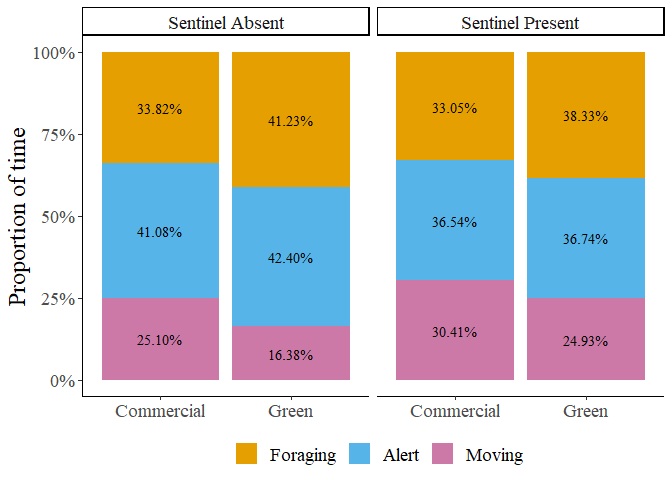

```r
PROP.BARPLOT<-ggplot(PROP.SUMMARY
                 , aes(x = GENERALIZED_ENVIRONMENT
                       , y = PROPORTION
                       , fill = BEHAVIOR))+
  geom_bar(stat = 'identity'
           , position = 'stack')+
  geom_text(aes(label = paste0(formattable::digits(PROPORTION*100, dig=2)
                               , "%"))
            , position = position_stack(vjust = 0.5)
            , size = 4
            , family = "serif") +
  scale_y_continuous(labels = scales::percent) +
  theme_classic()+
  ylab("Proportion of time")+
  scale_x_discrete(labels=c("Commercial"
                            , "Green"))+
  scale_fill_manual(values = cbPalette, labels = c("Foraging"
                                                   , "Alert"
                                                   , "Moving")
                    , name="")+
  theme(legend.position = "bottom"
        , text = element_text(size = 18, family = "serif")
        , axis.title.x = element_blank()) +
  facet_grid(~SENTINEL_PRESENCE)
PROP.BARPLOT
```

To better visualize the effects of generalized environment and sentinel presence, I calculated the mean proportion for each behavior and plotted a stacked barplot for each combination of factors.

## PROP Model

```r
PROP.MOD<-lm(PROPORTION~BEHAVIOR+SENTINEL_PRESENCE+GENERALIZED_ENVIRONMENT, data = subset(PROP, PROP$BEHAVIOR != "M"))

sjPlot::tab_model(PROP.MOD
                  , pred.labels = labs.prop
                  , show.stat = T
                  , show.se = T
                  , digits = 4
                  , show.re.var = T
                  , title = ""
                  , dv.labels = ""
                  , file = "Proportion_Table.html")
```

| Predictors | Estimates | std. Error | CI | Statistic | p |
| --- | --- | --- | --- | --- | --- |
| Intercept | 0.3658 | 0.0240 | 0.3185 – 0.4132 | 15.2636 | **<0.001** |
| Behavior | 0.0263 | 0.0226 | -0.0185 – 0.0710 | 1.1600 | 0.248 |
| Sentinel Presence | -0.0335 | 0.0234 | -0.0797 – 0.0127 | -1.4314 | 0.154 |
| Generalized Environment | 0.0336 | 0.0230 | -0.0118 – 0.0791 | 1.4625 | 0.146 |
| Observations | 154 |  |  |  |  |
| R<sup>2</sup> / R<sup>2</sup> adjusted | 0.037 / 0.018 |  |  |  |  |

A linear model was performed. While all behaviors were included in the model, “Moving” behavior was omitted from analysis, as not all bouts of movement were recorded in their entirety.

# Bout Data

```r
BOUT<-BOUT.raw %>%
  filter(.
         , DURATION > 0.01) %>% #Remove impossibly small values
  filter(.
         , BEHAVIOR != "M") %>% #Remove "M"
  mutate(SENTINEL_PRESENCE = recode_factor(SENTINEL_PRESENCE
                         , 'YES' = "Sentinel Present"
                         , 'NO' = "Sentinel Absent"))
BOUT$LDURATION<-log(BOUT$DURATION) #Transform data for normality
str(BOUT)
```

```
## 'data.frame':    3897 obs. of  16 variables:
##  $ VIDEO_ID               : Factor w/ 25 levels "037-2","038-2",..: 4 4 4 4 4 4 4 4 4 4 ...
##  $ ID                     : Factor w/ 67 levels "020-01-01","020-01-02",..: 1 1 1 1 1 1 1 1 1 1 ...
##  $ JULIAN_DATE            : int  20227825 20227825 20227825 20227825 20227825 20227825 20227825 20227825 20227825 20227825 ...
##  $ DECIMAL_TIME           : num  6.33 6.33 6.33 6.33 6.33 ...
##  $ LATITUDE               : num  43.2 43.2 43.2 43.2 43.2 ...
##  $ LONGITUDE              : num  -79.2 -79.2 -79.2 -79.2 -79.2 ...
##  $ TEMPERATURE            : int  18 18 18 18 18 18 18 18 18 18 ...
##  $ WEATHER                : Factor w/ 6 levels "Cloudy","Foggy",..: 6 6 6 6 6 6 6 6 6 6 ...
##  $ GROUP_SIZE             : Factor w/ 2 levels "LARGE","SMALL": 2 2 2 2 2 2 2 2 2 2 ...
##  $ BAIT_PRESENCE          : Factor w/ 2 levels "NO","YES": 1 1 1 1 1 1 1 1 1 1 ...
##  $ GENERALIZED_ENVIRONMENT: Factor w/ 2 levels "Commercial","Green Area": 2 2 2 2 2 2 2 2 2 2 ...
##  $ SENTINEL_PRESENCE      : Factor w/ 2 levels "Sentinel Present",..: 2 2 2 2 2 2 2 2 2 2 ...
##  $ DISTURBANCE_FREQUENCY  : num  0 0 0 0 0 0 0 0 0 0 ...
##  $ BEHAVIOR               : Factor w/ 3 levels "HD","HU","M": 1 1 1 1 1 1 1 1 1 1 ...
##  $ DURATION               : num  2.38 2.51 3.51 1.75 10.5 ...
##  $ LDURATION              : num  0.869 0.919 1.255 0.56 2.351 ...
```

In order to analyze the effects of generalized environment and the presence of a sentinel on the duration of bouts, I first removed all bouts of a duration shorter than 0.01s to remove impossibly small outliers (likely artifacts from video coding in BORIS, 21 observations removed), and removed all bouts where the individuals were moving as they were not always recorded in their entirety (1173 observations removed).

```r
BOUT.SUMMARY <- summarySE(data = BOUT
                      , measurevar = "DURATION"
                      , groupvars = c("GENERALIZED_ENVIRONMENT"
                                      , "BEHAVIOR"
                                      , "SENTINEL_PRESENCE"
                                      )
                      ) %>%
  mutate(BEHAVIOR = recode_factor(BEHAVIOR
                                  ,'HD' = 'Foraging'#Rename HD as 'foraging'
                                  , 'HU' = 'Alert') #Rename HU as 'Alert'
                           )

BOUT.SUMMARY
```

```
##   GENERALIZED_ENVIRONMENT BEHAVIOR SENTINEL_PRESENCE   N DURATION       sd
## 1              Commercial Foraging  Sentinel Present 503 1.760944 1.283057
## 2              Commercial Foraging   Sentinel Absent 336 1.500423 1.136791
## 3              Commercial    Alert  Sentinel Present 627 1.781003 2.173001
## 4              Commercial    Alert   Sentinel Absent 422 1.431455 1.611098
## 5              Green Area Foraging  Sentinel Present 673 2.010571 1.919007
## 6              Green Area Foraging   Sentinel Absent 275 2.272862 1.882358
## 7              Green Area    Alert  Sentinel Present 737 1.484700 2.025277
## 8              Green Area    Alert   Sentinel Absent 324 1.993713 2.949379
##           se        ci
## 1 0.05720870 0.1123980
## 2 0.06201706 0.1219919
## 3 0.08678130 0.1704177
## 4 0.07842704 0.1541574
## 5 0.07397229 0.1452446
## 6 0.11351045 0.2234634
## 7 0.07460204 0.1464582
## 8 0.16385436 0.3223565
```

## BOUT Dot Plot

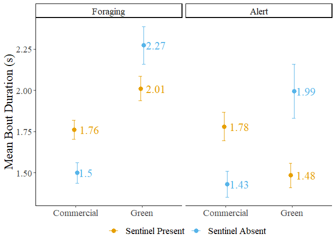

```r
BOUT.DOTPLOT<-BOUT.SUMMARY %>%
           ggplot(.
               , aes(x = GENERALIZED_ENVIRONMENT
                     , y = DURATION
                     , colour = SENTINEL_PRESENCE))+
  geom_point(position = position_dodge(width = 0.1)
             , size = 3
             ) +
  geom_errorbar(aes(ymin=(DURATION-se)
                    , ymax=(DURATION+se))
                , width = 0.1
                , position = position_dodge(width=0.1))+
  geom_text(aes(label = round(DURATION, 2))
            , hjust = -0.2
            , size = 6
            , show.legend = F
            , family = "serif") +
  theme_classic() +
  ylab("Mean Bout Duration (s)") +
  scale_colour_manual(values = cbPalette
                      , name = "") +
  scale_x_discrete(labels = c("Commercial", "Green"))+
  theme(axis.title.x = element_blank()
        , legend.position = "bottom"
        , legend.box="vertical"
        , legend.margin=margin()
        , text = element_text(size = 18, family = "serif")
        ) +
  facet_grid(~BEHAVIOR)

BOUT.DOTPLOT
```

> The error bars represent the standard error, while the symbols are the mean duration of bouts.

## BOUT Model - All behaviors

```r
BOUT.MOD<-rlmer(LDURATION~BEHAVIOR*SENTINEL_PRESENCE+BEHAVIOR*GENERALIZED_ENVIRONMENT+SENTINEL_PRESENCE*GENERALIZED_ENVIRONMENT+GROUP_SIZE+BAIT_PRESENCE+DISTURBANCE_FREQUENCY+(1|ID), data = BOUT)

sjPlot::tab_model(BOUT.MOD
                  , pred.labels = labs.bout.1
                  , show.re.var = T
                  , show.se = T
                  , show.stat = T
                  , digits = 4
                  , title = ""
                  , dv.labels = "")
```

| Predictors | Estimates | std. Error | CI | Statistic | p |
| --- | --- | --- | --- | --- | --- |
| Intercept | 0.5304 | 0.0942 | 0.3457 – 0.7151 | 5.6294 | **<0.001** |
| Behavior | -0.3366 | 0.0445 | -0.4239 – -0.2494 | -7.5589 | **<0.001** |
| Sentinel Presence | -0.1974 | 0.0720 | -0.3385 – -0.0562 | -2.7406 | **0.006** |
| Generalized Environment | 0.1010 | 0.0802 | -0.0561 – 0.2582 | 1.2601 | 0.208 |
| Group Size | -0.0046 | 0.0766 | -0.1548 – 0.1455 | -0.0603 | 0.952 |
| Bait Presence | -0.1430 | 0.0760 | -0.2920 – 0.0060 | -1.8811 | 0.060 |
| Disturbance Frequency | -0.0878 | 0.0295 | -0.1457 – -0.0300 | -2.9748 | **0.003** |
| Behavior: Sentinel Presence | 0.0810 | 0.0563 | -0.0294 – 0.1913 | 1.4382 | 0.150 |
| Behavior: Generalized Environment | -0.2023 | 0.0537 | -0.3074 – -0.0971 | -3.7690 | **<0.001** |
| Sentinel Presence: Generalized Environment | 0.2524 | 0.0882 | 0.0796 – 0.4251 | 2.8630 | **0.004** |
| Random Effects |  |  |  |  |  |
| σ<sup>2</sup> | 0.65 |  |  |  |  |
| τ<sub>00</sub> <sub>ID</sub> | 0.03 |  |  |  |  |
| ICC | 0.04 |  |  |  |  |
| N <sub>ID</sub> | 64 |  |  |  |  |
| Observations | 3897 |  |  |  |  |
| Marginal R<sup>2</sup> / Conditional R<sup>2</sup> | 0.076 / 0.113 |  |  |  |  |

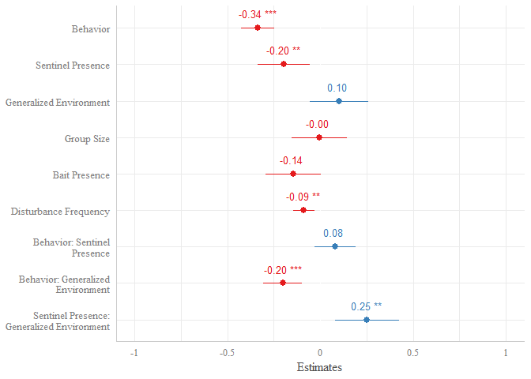

```r
sjPlot::plot_model(BOUT.MOD
                  , axis.labels = labs.bout.1
                  , show.values=T
                  , show.p=T
                  , value.offset = 0.4
                  , value.size = 3.5
                  , wrap.title = 48
                  , show.re.var = T
                  , title = ""
                  ) +
  theme_sjplot(base_family = "serif" )
```

I then visualized the data and ran a robust linear mixed model on the bouts of all behaviors using the following structure:

$Log(Bout Duration) ~ Behavior X Sentinel Presence + Behavior X Generalized Environment + Sentinel Presence X Generalized Environment + Group Size + Bait Presence + Disturbance Frequency + ( 1 | Individual ID ) $

Where the behavior, presence of a sentinel, generalized environment, group size, bait presence, and disturbance frequency are fixed effects, while the individual ID is the random effect.

I subsequently ran robust linear mixed models on each behavior separately, using a similar formula as described above.

The interaction between behavior type and generalized environment was also significant (Estimate = -0.2023, SE = 0.0537, t-stat = -3.7690, p = <0.001).

Lastly, disturbance frequency had a significant effect on the duration of all bouts (Estimate = -0.0878, SE = 0.0295, t-stat = -2.9748, p = 0.003), with bout duration decreasing as disturbance frequency increased.

```r
BOUT.DIFF.ALL_BEHAVIORS<-emmeans(BOUT.MOD, ~SENTINEL_PRESENCE*GENERALIZED_ENVIRONMENT, pbkrtest.limit = 5070)
kbl(test(pairs(BOUT.DIFF.ALL_BEHAVIORS), by = NULL, adjust="fdr"), format = "html", digits = 4, caption = "Bout post hoc - All behaviors", col.names = c("Contrast", "Estimate", "SE", "df", "z-ratio", "p"), align = "lccccc" )%>%
  kable_classic(html_font = "Times New Roman") %>%
  save_kable(file = "Bout_PH_All Behaviors.html", self_contained = T)
```

RESULTS Post-hoc pairwise testing revealed significant differences in the duration of all bouts. The following results are averaged over the levels of bait, group size and bait presence, and the p-values are adjusted using the ‘FDR’ method for 6 tests. In commercial areas, the presence of a sentinel increased the duration of foraging bouts (Estimate = -0.157, SE = 0.0653, z-ratio = -2.402, p = 0.0489). In the absence of a sentinel, foragers in green areas had longer foraging bouts (Estimate = -0.252, SE = 0.0821, z-ratio = -3.074, p = 0.0127). Foragers in commercial areas and in the absence of a sentinel had a marginally significant effect, shortening foraging bouts in green areas and in the presence of a sentinel (Estimate = -0.157, SE = 0.0720, z-ratio = -2.117, p = 0.0589). All other comparisons were not significant (p < 0.3430)

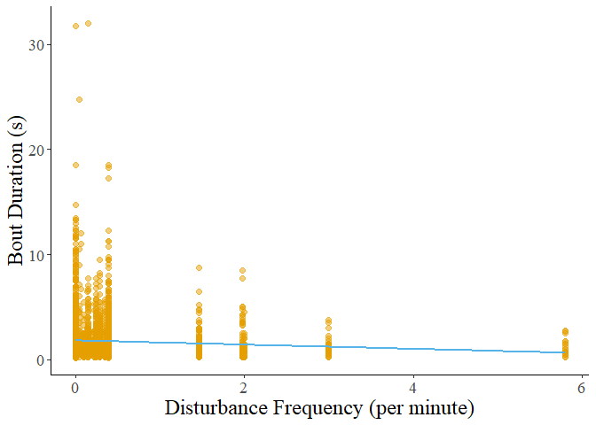

```r
BOUT.DOTPLOT.DISTURBANCES<-BOUT %>%
           ggplot(.
               , aes(x = DISTURBANCE_FREQUENCY
                     , y = DURATION
                     ))+
  geom_point(size = 2
             , colour = cbPalette[1]
             , alpha = 0.5
             )+
  geom_smooth(method = "lm"
              , se = F
              , colour = cbPalette [2]) +
  theme_classic() +
  xlab("Disturbance Frequency (per minute)") +
  ylab("Bout Duration (s)") +
  theme(legend.position = "none"
        , text = element_text(size = 18, family = "serif")
        )

BOUT.DOTPLOT.DISTURBANCES
```

##BOUT Model - Head Down

```r
BOUT.MOD.HD<-rlmer(LDURATION~SENTINEL_PRESENCE*GENERALIZED_ENVIRONMENT+GROUP_SIZE+BAIT_PRESENCE+DISTURBANCE_FREQUENCY+(1|ID), data = subset(BOUT, BEHAVIOR == "HD"))

sjPlot::tab_model(BOUT.MOD.HD
                  , pred.labels = labs.bout.2
                  , show.re.var = T
                  , show.se = T
                  , show.stat = T
                  , digits = 4
                  , title = ""
                  , dv.labels = "")
```

| Predictors | Estimates | std. Error | CI | Statistic | p |
| --- | --- | --- | --- | --- | --- |
| Intercept | 0.5289 | 0.0832 | 0.3658 – 0.6920 | 6.3562 | **<0.001** |
| Sentinel Presence | -0.0919 | 0.0718 | -0.2327 – 0.0488 | -1.2799 | 0.201 |
| Generalized Environment | 0.1555 | 0.0665 | 0.0251 – 0.2858 | 2.3371 | **0.019** |
| Group Size | -0.1519 | 0.0684 | -0.2860 – -0.0178 | -2.2205 | **0.026** |
| Bait Presence | -0.1385 | 0.0697 | -0.2751 – -0.0020 | -1.9885 | **0.047** |
| Disturbance Frequency | -0.1075 | 0.0301 | -0.1665 – -0.0484 | -3.5664 | **<0.001** |
| Sentinel Presence: Generalized Environment | 0.2272 | 0.0914 | 0.0480 – 0.4063 | 2.4849 | **0.013** |
| Random Effects |  |  |  |  |  |
| σ<sup>2</sup> | 0.45 |  |  |  |  |
| τ<sub>00</sub> <sub>ID</sub> | 0.01 |  |  |  |  |
| ICC | 0.03 |  |  |  |  |
| N <sub>ID</sub> | 64 |  |  |  |  |
| Observations | 1787 |  |  |  |  |
| Marginal R<sup>2</sup> / Conditional R<sup>2</sup> | 0.050 / 0.075 |  |  |  |  |

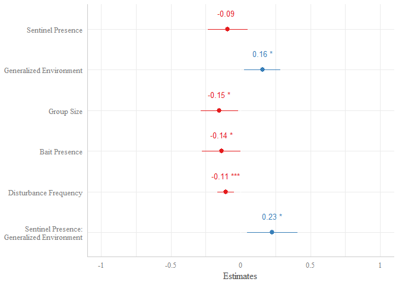

```r
sjPlot::plot_model(BOUT.MOD.HD
                  , axis.labels = labs.bout.2
                  , show.values=T
                  , show.p=T
                  , value.offset = 0.4
                  , value.size = 3.5
                  , wrap.title = 48
                  , show.re.var = T
                  , title = "") +
  theme_sjplot(base_family = "serif")
```

Increasing group size significantly increased the duration of bouts of foraging behavior (Estimate = -0.1519, SE = 0.0684, t-stat = -2.2205, p = 0.026).

The presence of bait decreased the duration of foraging bouts (Estimate = -0.1385, SE = 0.0697, t-stat = -1.9885, p = 0.047).

Increasing disturbance frequency significantly decreased the duration of foraging bouts (Estimate = -0.1075, SE = 0.0301, t-stat = -3.5664, p = <0.001).

```r
BOUT.DIFF.HD<-emmeans(BOUT.MOD.HD, ~SENTINEL_PRESENCE*GENERALIZED_ENVIRONMENT, pbkrtest.limit = 5070)
kbl(test(pairs(BOUT.DIFF.HD), by = NULL, adjust="fdr"), format = "html", digits = 4, caption = "Bout post hoc - Foraging", col.names = c("Contrast", "Estimate", "SE", "df", "z-ratio", "p"), align = "lccccc" )%>%
  kable_classic(html_font = "Times New Roman") %>%
  save_kable(file = "Bout_PH_HD.html", self_contained = T)
```

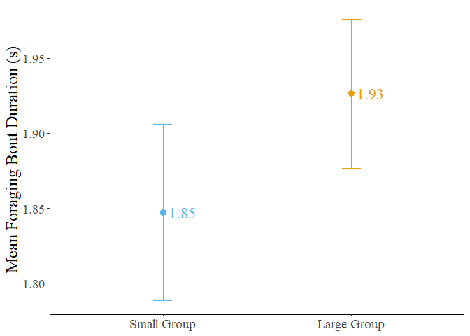

```r
BOUT.DOTPLOT.GROUP_SIZE<-BOUT %>%
  filter(., BEHAVIOR == "HD") %>%
  summarySE(., measurevar = "DURATION", groupvar = "GROUP_SIZE") %>%
           ggplot(.
               , aes(x = GROUP_SIZE
                     , y = DURATION
                     , colour = GROUP_SIZE
                     ))+
  geom_point(position = position_dodge(width = 0.1)
             , size = 3
             ) +
  geom_errorbar(aes(ymin=(DURATION-se)
                    , ymax=(DURATION+se))
                , width = 0.1
                , position = position_dodge(width=0.1))+
  geom_text(aes(label = round(DURATION, 2))
            , hjust = -0.2
            , size = 6
            , show.legend = F
            , family = "serif"
            ) +
  theme_classic() +
  xlab("Group Size") +
  ylab("Mean Foraging Bout Duration (s)") +
  scale_color_manual(values = cbPalette) +
  scale_x_discrete(labels = c("Small Group"
                                  , "Large Group")
                   , limits = c("SMALL", "LARGE")) +
  theme(axis.title.x = element_blank()
        , legend.position = "none"
        , legend.box="vertical"
        , legend.margin=margin()
        , text = element_text(size = 18, family = "serif")
        )

BOUT.DOTPLOT.GROUP_SIZE
```

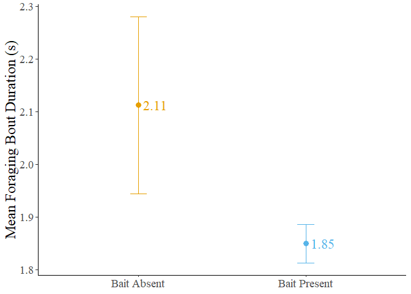

```r
BOUT.DOTPLOT.BAIT<-BOUT %>%
  filter(., BEHAVIOR == "HD") %>%
  summarySE(., measurevar = "DURATION", groupvar = "BAIT_PRESENCE") %>%
           ggplot(.
               , aes(x = BAIT_PRESENCE
                     , y = DURATION
                     , colour = BAIT_PRESENCE
                     ))+
  geom_point(position = position_dodge(width = 0.1)
             , size = 3
             ) +
  geom_errorbar(aes(ymin=(DURATION-se)
                    , ymax=(DURATION+se))
                , width = 0.1
                , position = position_dodge(width=0.1))+
  geom_text(aes(label = round(DURATION, 2))
            , hjust = -0.2
            , size = 6
            , show.legend = F
            , family = "serif") +
  theme_classic() +
  ylab("Mean Foraging Bout Duration (s)") +
  scale_color_manual(values = cbPalette) +
  scale_x_discrete(labels = c("Bait Absent"
                                  , "Bait Present")) +
  theme(axis.title.x = element_blank()
        , legend.position = "none"
        , legend.box="vertical"
        , legend.margin=margin()
        , text = element_text(size = 18, family = "serif")
        )

BOUT.DOTPLOT.BAIT
```

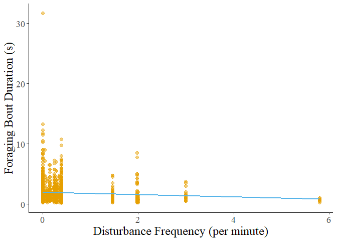

```r
BOUT.DOTPLOT.DISTURBANCES.HD<-BOUT %>%
  filter(., BEHAVIOR == "HD") %>%
           ggplot(.
               , aes(x = DISTURBANCE_FREQUENCY
                     , y = DURATION
                     ))+
  geom_point(size = 2
             , colour = cbPalette[1]
             , alpha = 0.5
             )+
  geom_smooth(method = "lm"
              , se = F
              , colour = cbPalette [2]) +
  theme_classic() +
  xlab("Disturbance Frequency (per minute)") +
  ylab("Foraging Bout Duration (s)") +
  theme(legend.position = "none"
        , text = element_text(size = 18, family = "serif")
        )

BOUT.DOTPLOT.DISTURBANCES.HD
```

## BOUT Model - Head Up

```r
BOUT.MOD.HU<-rlmer(LDURATION~SENTINEL_PRESENCE*GENERALIZED_ENVIRONMENT+GROUP_SIZE+BAIT_PRESENCE+DISTURBANCE_FREQUENCY+(1|ID), data = subset(BOUT, BEHAVIOR == "HU"))

sjPlot::tab_model(BOUT.MOD.HU
                  , pred.labels = labs.bout.2
                  , show.re.var = T
                  , show.se = T
                  , show.stat = T
                  , digits = 4
                  , title = "Head Up"
                  , dv.labels = " Effects on alert bout duration")+
  theme_sjplot(base_family = "serif")
```

[output not shown]

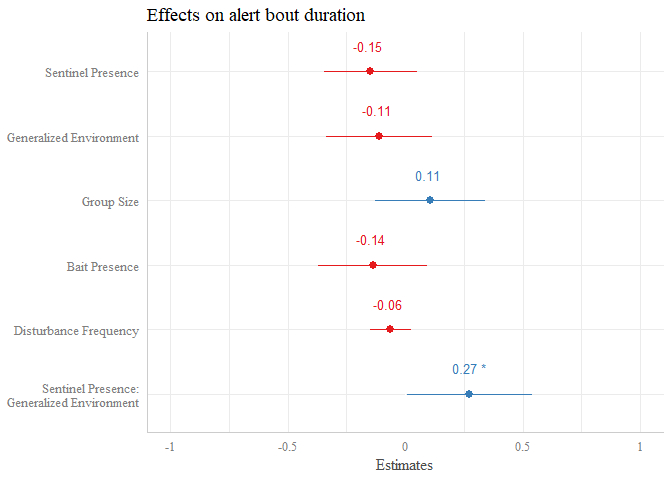

```r
sjPlot::plot_model(BOUT.MOD.HU
                  , axis.labels = labs.bout.2
                  , show.values=T
                  , show.p=T
                  , value.offset = 0.4
                  , value.size = 3.5
                  , wrap.title = 48
                  , show.re.var = T
                  , title = "Effects on alert bout duration") +
  theme_sjplot(base_family = "serif")
```

RESULTS: In contrast to foraging behavior, generalized environment, group size, bait presence and disturbance frequency had no significant effect on the duration of bouts of alert behavior (p < 0.141).

Sentinel behavior did not have an effect on the duration of alert behavior.

#Peck Rate

```r
PECK<-DATA.SR[,c(1,2,15,17,19,22,30,38,48)] %>%
  subset(., HD_BEHAVIOR_DURATION > 0) %>%
  rename("DISTURBANCE_FREQUENCY" = "TOTAL_FREQUENCY_OF_DISTURBANCES")

str(PECK)
```

```
## 'data.frame':    79 obs. of  9 variables:
##  $ VIDEO_ID               : Factor w/ 25 levels "037-2","038-2",..: 4 4 5 5 5 6 7 8 9 10 ...
##  $ ID                     : Factor w/ 64 levels "020-01-01","020-01-02",..: 1 2 3 3 4 5 6 7 8 9 ...
##  $ GENERALIZED_ENVIRONMENT: Factor w/ 2 levels "Commercial","Green Area": 2 2 2 2 2 2 2 2 2 2 ...
##  $ SENTINEL_PRESENCE      : Factor w/ 2 levels "NO","YES": 1 1 1 2 1 1 2 1 2 1 ...
##  $ BAIT_PRESENCE          : Factor w/ 2 levels "NO","YES": 1 1 1 1 1 2 2 2 2 2 ...
##  $ GROUP_SIZE             : Factor w/ 2 levels "LARGE","SMALL": 2 2 2 2 2 2 2 2 2 2 ...
##  $ DISTURBANCE_FREQUENCY  : num  0 0 0 0 0 ...
##  $ HD_BEHAVIOR_DURATION   : num  39.76 18.77 22.15 4.22 9.25 ...
##  $ PECK_RATE              : num  46.8 63.9 24.4 14.2 13 ...
```

The peck rate was calculated for every individual by dividing the total number of pecks at food performed by the total duration of foraging (or ‘Head Down’) behavior. Individuals that did not forage were excluded.

```
##   GENERALIZED_ENVIRONMENT SENTINEL_PRESENCE  N PECK_RATE       sd       se
## 1              Commercial                NO 17  59.80777 20.28898 4.920800
## 2              Commercial               YES 30  75.37699 24.01898 4.385246
## 3              Green Area                NO 13  55.99726 19.95921 5.535689
## 4              Green Area               YES 19  51.68760 24.07706 5.523656
##          ci
## 1 10.431630
## 2  8.968835
## 3 12.061229
## 4 11.604770
```

## PECK Dot Plot

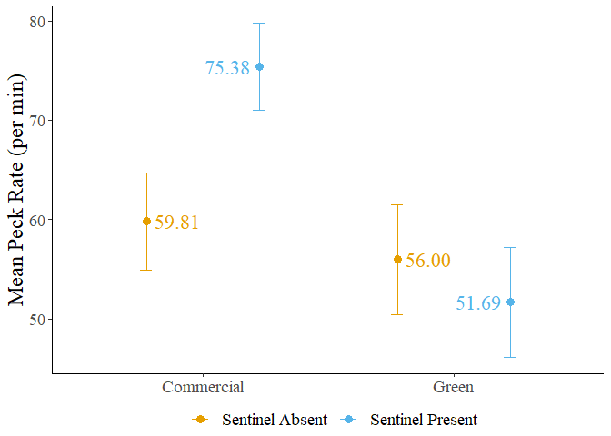

```r
PECK.DOTPLOT<-ggplot(data = PECK.SUMMARY
               , aes(x = GENERALIZED_ENVIRONMENT
                     , y = PECK_RATE
                     , color = SENTINEL_PRESENCE))+
  geom_point(position = position_dodge(width = 0.9)
             , size = 3
             ) +
  geom_errorbar(aes(ymin=(PECK_RATE-se)
                    , ymax=(PECK_RATE+se))
                , width = 0.1
                , position = position_dodge(width=0.9))+
  geom_text(aes(label = scales::label_number(accuracy=0.01)(PECK_RATE))
            , position = position_dodge(width = 0.4)
            , size = 6
            , show.legend = F
            , family = "serif"
            ) +
  theme_classic() +
  ylab("Mean Peck Rate (per min)") +
  scale_colour_manual(values = cbPalette
                      , labels = c("Sentinel Absent", "Sentinel Present")
                      , name = "")+
  scale_x_discrete(labels = c("Commercial"
                                  , "Green")) +
  theme(axis.title.x = element_blank()
        , legend.position = "bottom"
        , legend.box="vertical"
        , legend.margin=margin()
        , text = element_text(size = 18, family = "serif"))

PECK.DOTPLOT
```

## PECK Model

I then ran another robust linear mixed model using a similar formula as for the bout duration. Sentinel presence, generalized environment, group size, bait presence and the total frequency of disturbances per minute were used as fixed effects, with the individual ID used as a random factor.

```r
PECK.MOD<-rlmer(PECK_RATE~SENTINEL_PRESENCE*GENERALIZED_ENVIRONMENT+GENERALIZED_ENVIRONMENT*DISTURBANCE_FREQUENCY+GROUP_SIZE+BAIT_PRESENCE+(1|ID), data = PECK)

sjPlot::tab_model(PECK.MOD
                  , pred.labels = labs.peck
                  , show.re.var = T
                  , show.se = T
                  , show.stat = T
                  , digits = 4
                  , title = ""
                  , dv.labels = ""
                  , file = "Peck_Table.html")
```

| Predictors | Estimates | std. Error | CI | Statistic | p |
| --- | --- | --- | --- | --- | --- |
| Intercept | 54.3410 | 7.5358 | 39.5710 – 69.1109 | 7.2110 | **<0.001** |
| Sentinel Presence | -0.8275 | 6.4243 | -13.4190 – 11.7640 | -0.1288 | 0.898 |
| Generalized Environment | -2.7678 | 7.2437 | -16.9652 – 11.4295 | -0.3821 | 0.702 |
| Disturbance Frequency | 5.2900 | 2.2877 | 0.8061 – 9.7739 | 2.3123 | **0.021** |
| Group Size | -6.8477 | 5.7369 | -18.0918 – 4.3963 | -1.1936 | 0.233 |
| Bait Presence | 13.9915 | 6.0294 | 2.1742 – 25.8089 | 2.3206 | **0.020** |
| Sentinel Presence: Generalized Environment | -13.1026 | 9.0853 | -30.9094 – 4.7042 | -1.4422 | 0.149 |
| Generalized Environment: Disturbance Frequency | 16.1482 | 5.3012 | 5.7580 – 26.5383 | 3.0461 | **0.002** |
| Random Effects |  |  |  |  |  |
| σ<sup>2</sup> | 308.60 |  |  |  |  |
| τ<sub>00</sub> <sub>ID</sub> | 0.00 |  |  |  |  |
| ICC | 0.00 |  |  |  |  |
| N <sub>ID</sub> | 64 |  |  |  |  |
| Observations | 79 |  |  |  |  |
| Marginal R<sup>2</sup> / Conditional R<sup>2</sup> | 0.395 / 0.395 |  |  |  |  |

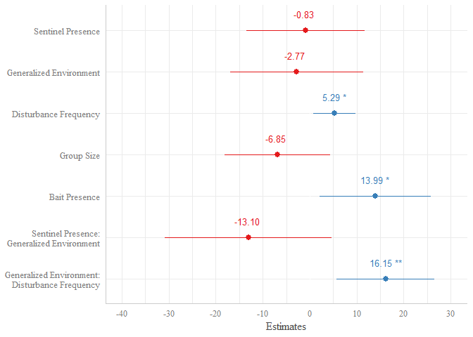

```r
sjPlot::plot_model(PECK.MOD
                  , axis.labels = labs.peck
                  , show.values=T
                  , show.p=T
                  , value.offset = 0.4
                  , value.size = 3.5
                  , wrap.title = 48
                  , show.re.var = T
                  , title = "" ) +
  theme_sjplot(base_family = "serif")
```

RESULTS Neither the presence of a sentinel nor the generalized environment alone had a significant effect on the peck rate of foragers (p > 0.702).

Peck rate increases significantly as disturbance frequency increases (Estimate = 5.29, t = 2.312, p = 0.021), with the interaction between generalized environment and disturbance frequency also significantly affecting peck rate (Estimate = 16.15, t = 3.046, p = 0.002).

## Disturbance Frequency x Generalized Environment

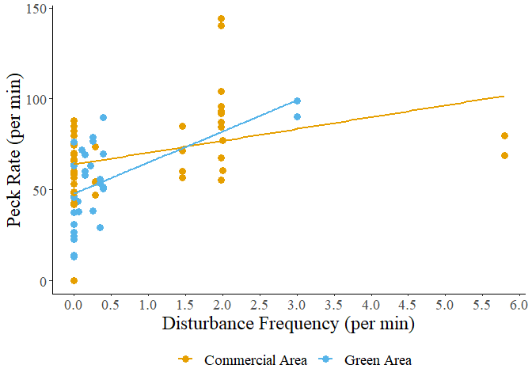

```r
PECK.DOTPLOT.DISTURBANCE<-PECK %>%
    ggplot(aes(x = DISTURBANCE_FREQUENCY
               , y = PECK_RATE
               , color = GENERALIZED_ENVIRONMENT))+
  geom_point(size = 3) +
  geom_smooth(method = "lm", se = F) +
  theme_classic() +
  labs(y="Peck Rate (per min)", x="Disturbance Frequency (per min)")+
  scale_x_continuous(n.breaks=14)+
  theme(legend.position = "bottom"
        , text = element_text(size = 18, family = "serif"))+
  scale_color_manual(values = cbPalette
                    , labels = c("Commercial Area"
                                 , "Green Area")
                    , name="")


PECK.DOTPLOT.DISTURBANCE
```

RESULTS Green areas appear to have much fewer disturbances than commercial areas.

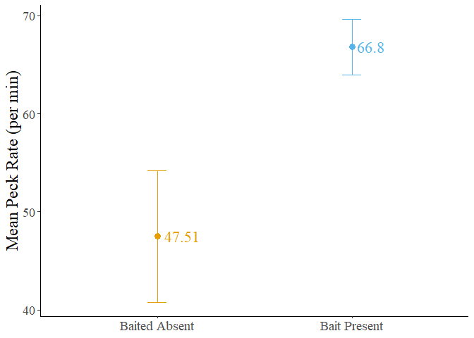

```r
PECK.DOTPLOT.BAIT<-PECK %>%
  summarySE(.
            , measurevar = "PECK_RATE"
            , groupvars = "BAIT_PRESENCE") %>%
  ggplot(.
         , aes(x = BAIT_PRESENCE
                     , y = PECK_RATE
                     , colour = BAIT_PRESENCE
               ))+
  geom_point(position = position_dodge(width = 0.1)
             , size = 3
             ) +
  geom_errorbar(aes(ymin=(PECK_RATE-se)
                    , ymax=(PECK_RATE+se))
                , width = 0.1
                , position = position_dodge(width=0.1))+
  geom_text(aes(label = round(PECK_RATE, 2))
            , hjust = -0.2
            , size = 6
            , show.legend = F
            , family = "serif") +
  theme_classic() +
  ylab("Mean Peck Rate (per min)") +
  scale_x_discrete(labels = c("Baited Absent"
                                  , "Bait Present")) +
  scale_color_manual(values = cbPalette) +
  theme(axis.title.x = element_blank()
        , legend.position = "none"
        , legend.box="vertical"
        , legend.margin=margin()
        , text = element_text(size = 18, family = "serif"))

PECK.DOTPLOT.BAIT
```

# Sentinel Likelihood

```r
SENT<-DATA.SR[1:81,c(1,7,10,15,17,19,20,22,30,31)] %>%
  distinct()
str(SENT)
```

```
## 'data.frame':    33 obs. of  10 variables:
##  $ VIDEO_ID                       : Factor w/ 25 levels "037-2","038-2",..: 4 5 5 6 7 8 9 10 10 11 ...
##  $ DECIMAL_TIME                   : num  6.33 6.22 6.22 6.3 6.52 ...
##  $ TEMPERATURE                    : int  18 16 16 16 19 22 24 21 21 22 ...
##  $ GENERALIZED_ENVIRONMENT        : Factor w/ 2 levels "Commercial","Green Area": 2 2 2 2 2 2 2 2 2 2 ...
##  $ SENTINEL_PRESENCE              : Factor w/ 2 levels "NO","YES": 1 1 2 1 2 1 2 1 2 2 ...
##  $ BAIT_PRESENCE                  : Factor w/ 2 levels "NO","YES": 1 1 1 2 2 2 2 2 2 2 ...
##  $ NUMBER_OF_CROWS_RECORDED       : int  2 2 2 1 1 1 1 2 2 1 ...
##  $ GROUP_SIZE                     : Factor w/ 2 levels "LARGE","SMALL": 2 2 2 2 2 2 2 2 2 2 ...
##  $ TOTAL_FREQUENCY_OF_DISTURBANCES: num  0 0 0 0.142 0.223 ...
##  $ DISTURBANCE_FREQUENCY          : Factor w/ 3 levels "HIGH","LOW","MEDIUM": 2 2 2 3 3 3 3 3 3 2 ...
```

A chi-squared test was performed to determine if there were environmental or social factors that affected the likelihood of a sentinel being present in our videos.

```r
SENT.SUMMARY <- summarySE(data = SENT
                      , measurevar = "GROUP_SIZE" #Random
                      , groupvars = c("GENERALIZED_ENVIRONMENT"
                                      , "SENTINEL_PRESENCE"
                                      )
                      )

SENT.SUMMARY
```

```
##   GENERALIZED_ENVIRONMENT SENTINEL_PRESENCE  N GROUP_SIZE        sd         se
## 1              Commercial                NO  6   1.666667 0.5163978 0.21081851
## 2              Commercial               YES  7   1.571429 0.5345225 0.20203051
## 3              Green Area                NO  8   2.000000 0.0000000 0.00000000
## 4              Green Area               YES 12   1.916667 0.2886751 0.08333333
##          ci
## 1 0.5419262
## 2 0.4943508
## 3 0.0000000
## 4 0.1834154
```

## SENT Barplot

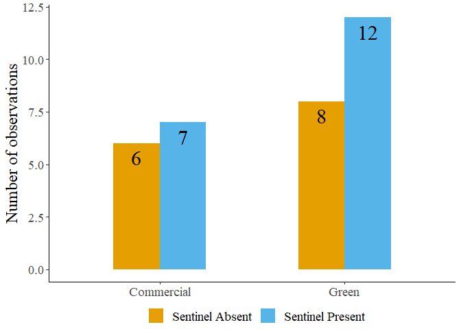

```r
SENT.BARPLOT <- ggplot(SENT.SUMMARY, aes(x=GENERALIZED_ENVIRONMENT
                 , fill = SENTINEL_PRESENCE
                 , y = N
                 , group = SENTINEL_PRESENCE)) +
  geom_bar(stat='identity', width=.5, position = "dodge") +
  geom_text(aes(label = N, group = SENTINEL_PRESENCE)
            , position = position_dodge(width = 0.5)
            , vjust = 1.5
            , size = 8
            , family = "serif") +
  ylab("Number of observations") +
  theme_classic() +
  scale_fill_manual(""
                    , values = cbPalette
                    , labels = c("Sentinel Absent", "Sentinel Present")
                      ) +
  scale_x_discrete(labels = c("Commercial"
                              , "Green")) +
  theme(axis.title.x = element_blank()
        , text = element_text(size = 18, family = "serif")
        , legend.position = "bottom"
        , legend.box="vertical"
        , legend.margin=margin())

SENT.BARPLOT
```

## SENT Chi-Squared

```r
SENT.CHISQ<-lapply(SENT[,c("GENERALIZED_ENVIRONMENT"
                      , "GROUP_SIZE"
                      , "DISTURBANCE_FREQUENCY"
                      )
                              ]
                         , function(x) CrossTable(x,SENT$SENTINEL_PRESENCE
                                                  , fisher = T
                                                  , chisq = T
                                                  , expected = T
                                                  , prop.c = F
                                                  , prop.t = F
                                                  , prop.chisq = F
                                                  , sresid = T
                                                  , format = 'SPSS'
                                                  )
                         )
SENT.CHISQ
```

```
## $GENERALIZED_ENVIRONMENT
##    Cell Contents
## |-------------------------|
## |                   Count |
## |         Expected Values |
## |             Row Percent |
## |            Std Residual |
## |-------------------------|
##
## =====================================
##               SENT$SENTINEL_PRESENCE
## x                 NO      YES   Total
## -------------------------------------
## Commercial        6        7      13
##                 5.5      7.5
##                46.2%    53.8%   39.4%
##               0.206   -0.177
## -------------------------------------
## Green Area        8       12      20
##                 8.5     11.5
##                40.0%    60.0%   60.6%
##              -0.166    0.143
## -------------------------------------
## Total            14       19      33
## =====================================
##
## Statistics for All Table Factors
##
## Pearson's Chi-squared test
## ------------------------------------------------------------
## Chi^2 = 0.1221515      d.f. = 1      p = 0.727
##
## Pearson's Chi-squared test with Yates' continuity correction
## ------------------------------------------------------------
## Chi^2 = 0      d.f. = 1      p = 1
##
##
## Fisher's Exact Test for Count Data
## ------------------------------------------------------------
## Sample estimate odds ratio: 1.275883
```

[output cut: 103 more lines]

```
##
## Statistics for All Table Factors
##
## Pearson's Chi-squared test
## ------------------------------------------------------------
## Chi^2 = 2.032678      d.f. = 2      p = 0.362
##
##
##
## Fisher's Exact Test for Count Data
## ------------------------------------------------------------
## Alternative hypothesis: two.sided
## p = 0.476
##         Minimum expected frequency: 2.545455
## Cells with Expected Frequency < 5: 2 of 6 (33.33333%)
```

RESULTS Neither the generalized environment (Chi^2 = 0.1221515, df = 1, p = 0.727), group size (Chi^2 = 0.2481203, df = 1, p = 0.618 ), or the disturbance frequency (Chi^2 = 2.032678, df = 2, p = 0.362) significantly affected the likelihood of a sentinel being present.

##SENT Plots - Continuous Variables

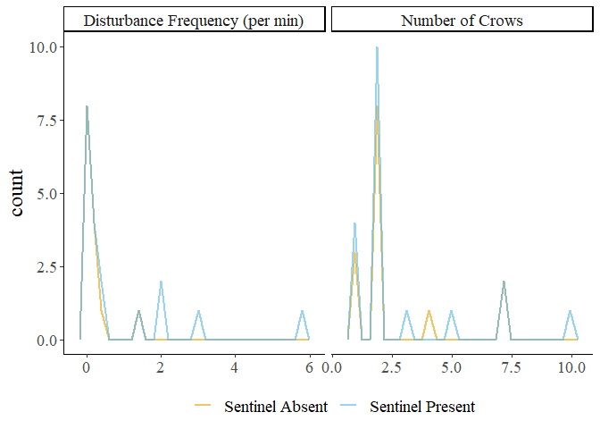

```r
SENT.FREQ <- SENT %>%
  rename("Temperature (deg. C)" = "TEMPERATURE"
         , "Decimal Time" = "DECIMAL_TIME"
         , "Disturbance Frequency (per min)" = "TOTAL_FREQUENCY_OF_DISTURBANCES"
         , "Number of Crows" = "NUMBER_OF_CROWS_RECORDED") %>%
  pivot_longer(., cols = c(#"Temperature (deg. C)"
                           # , "Decimal Time"
                           "Number of Crows"
                           , "Disturbance Frequency (per min)")
               , names_to = "Var"
               , values_to = "Val") %>%
  ggplot(aes(
    x = Val
    , colour = SENTINEL_PRESENCE))+
  geom_freqpoly(linewidth = 1
                , alpha=I(.6)) +
  scale_colour_manual(values = cbPalette
                      , name = ""
                      , labels = c("Sentinel Absent"
                                   , "Sentinel Present")) +
  facet_wrap(~Var, scale = "free_x") +
  theme_classic() +
  theme(legend.position = "bottom"
        , axis.title.x = element_blank()
        , text = element_text(size = 18, family = "serif"))

SENT.FREQ
```

# Pathway Analysis

I calculated the likelihood of one behavior following another by dividing the number of transitions from one behavior to another by the total number of transitions from that behavior.

```r
PTWY<- DATA.SR %>%
  dplyr::select(VIDEO_ID,ID, DECIMAL_TIME, GENERALIZED_ENVIRONMENT, SENTINEL_PRESENCE, BAIT_PRESENCE, NUMBER_OF_CROWS_RECORDED, GROUP_SIZE, TOTAL_NB_TRANSITIONS, TOTAL_FREQUENCY_OF_DISTURBANCES | starts_with("NB_")) %>%
  rename("DISTURBANCE_FREQUENCY" = "TOTAL_FREQUENCY_OF_DISTURBANCES"
         , "Transitions" = "TOTAL_NB_TRANSITIONS") %>%
  mutate(SENTINEL_PRESENCE = recode_factor(SENTINEL_PRESENCE
                         , 'YES' = "Sentinel Present"
                         , 'NO' = "Sentinel Absent"))
```

### PTWY Plots

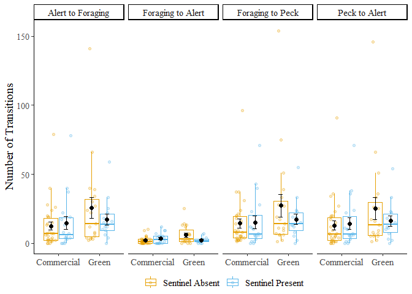

```r
PTWY.SUMMARY<-PTWY %>%
  rename("Foraging to Peck" = "NB_HD.HDP"
         , "Alert to Foraging" = "NB_HU.HD"
         , "Foraging to Alert" = "NB_HD.HU"
         , "Peck to Alert" = "NB_HDP.HU"
         ) %>%
  pivot_longer(., cols = c("Foraging to Peck"
                           , "Alert to Foraging"
                           , "Foraging to Alert"
                           , "Peck to Alert"
                           )
               , names_to = "TRANSITION"
               , values_to = "PTWY") %>%
  summarySE(.
            , measurevar = "PTWY"
            , groupvars = c("TRANSITION"
                            , "SENTINEL_PRESENCE"
                            , "GENERALIZED_ENVIRONMENT"))

PTWY.BOXPLOT<-PTWY %>%
  rename("Foraging to Peck" = "NB_HD.HDP"
         , "Alert to Foraging" = "NB_HU.HD"
         , "Foraging to Alert" = "NB_HD.HU"
         , "Peck to Alert" = "NB_HDP.HU"
         ) %>%
  pivot_longer(., cols = c("Foraging to Peck"
                           , "Alert to Foraging"
                           , "Foraging to Alert"
                           , "Peck to Alert"
                           )
               , names_to = "TRANSITION"
               , values_to = "PTWY") %>%
    ggplot(.
           , aes(x = GENERALIZED_ENVIRONMENT
                 , y = PTWY
                 , colour = SENTINEL_PRESENCE)) +
  geom_boxplot(outlier.shape = NA) +
  geom_jitter(aes(x = GENERALIZED_ENVIRONMENT
                  , group = SENTINEL_PRESENCE)
              , position = position_jitterdodge(jitter.width = 0.5)
              , alpha = 0.25
              ) +
  geom_point(data = PTWY.SUMMARY
             , aes( x = GENERALIZED_ENVIRONMENT
                    , y = PTWY
                    , group = SENTINEL_PRESENCE)
             , size = 2
             , colour = "black"
             , position = position_dodge(width = 0.75)) +
  geom_errorbar(data = PTWY.SUMMARY
                , aes(ymin=(PTWY-se)
                    , ymax=(PTWY+se)
                    , group = SENTINEL_PRESENCE
                    , x = GENERALIZED_ENVIRONMENT)
                , width = 0.2
                , colour = "black"
                , position = position_dodge(width=0.75
                                            )) +
  theme_classic() +
  ylab("Number of Transitions") +
  scale_colour_manual(values = cbPalette
                      , labels = c("Sentinel Absent"
                                   , "Sentinel Present")
                      , name = "") +
  scale_x_discrete(labels = c("Commercial", "Green")
                   )+
  theme(axis.title.x = element_blank()
        , legend.position = "bottom"
        , legend.box="vertical"
        , legend.margin=margin()
        , text = element_text(size = 14, family = "serif")
        ) +
  facet_grid(~TRANSITION)

PTWY.BOXPLOT
```

### GLMM

A generalized linear mixed model with a poisson distribution was performed to assess changes in the frequency of transitions to each behavior. Sentinel presence, generalized environment, disturbance frequency and bait presence were used as fixed effects, with the total number of transitions as a random effect.

```r
PTWY.MODELS<-list()
DV<-list("NB_HD.HU"
         , "NB_HD.HDP"
         , "NB_HU.HD"
         , "NB_HDP.HU"
         )


for (y in DV){
  formula<-formula(paste(y,"~SENTINEL_PRESENCE*GENERALIZED_ENVIRONMENT+DISTURBANCE_FREQUENCY+BAIT_PRESENCE+(1|Transitions)"))
  PTWY.MODELS[[y]]<-glmer(formula, data = PTWY, family = "poisson", control=glmerControl(optimizer="bobyqa", optCtrl=list(maxfun=100000)))
}

tab_model(PTWY.MODELS
          , pred.labels = labs.ptwy
                  , show.re.var = T
                  , show.se = T
                  , show.stat = T
                  , digits = 4
                  , title = ""
                  , dv.labels = c("Foraging to Alert"
                                  , "Foraging to Peck"
                                  , "Alert to Foraging"
                                  , "Peck to Alert")
          )+
  theme_sjplot(base_family = "serif")
```

[output not shown]

```r
PTWY.DIFF<-emmeans(PTWY.MODELS$NB_HD.HU, ~SENTINEL_PRESENCE*GENERALIZED_ENVIRONMENT)
kbl(test(pairs(PTWY.DIFF), by = NULL, adjust="fdr"), format = "html", digits = 4, caption = "Pathway analysis post hoc", col.names = c("Contrast", "Estimate", "SE", "df", "z-ratio", "p"), align = "lccccc" )%>%
  kable_classic(html_font = "Times New Roman") %>%
  save_kable(file = "PTWY_PH.html", self_contained = T)
```

RESULTS Transitions from head down to pecking were significantly affected by the presence of bait, with more transitions occuring in the presence of bait (IRR = 1.7096, SE = 0.3842, z-stat = 2.3858, p = 0.017). All other factors did not affect this transition.

Transitions from pecking to head up were similarly affected by the presence of bait, significantly increasing when bait was present (IRR = 2.2037, SE = 0.5378, z-stat = 3.2378, p = 0.001).

Transitions from head up to head down were not affected by any factors, but bait presence had a marginally significant effect (IRR = 1.5134, SE = 0.3506, z-stat - 1.7888, p = 0.074). In the presence of bait, the number of transitions from head up to head down appears to increase.

Transitions from head down to head up, from vulnerability to vigilance, were significantly affected by generalized environment, disturbance frequency, and the interaction between generalized environment and sentinel presence.

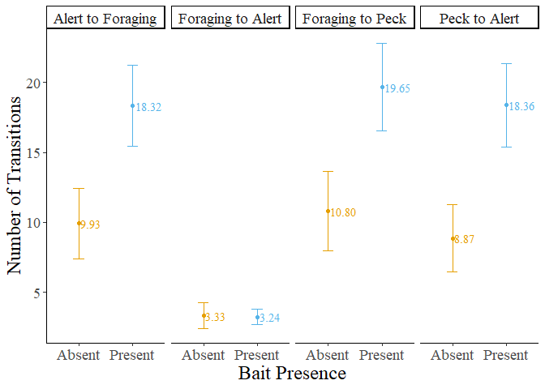

```r
PTWY.DOTPLOT.BAIT<-PTWY %>%
  rename("Foraging to Peck" = "NB_HD.HDP"
         , "Alert to Foraging" = "NB_HU.HD"
         , "Foraging to Alert" = "NB_HD.HU"
         , "Peck to Alert" = "NB_HDP.HU"
         ) %>%
  pivot_longer(., cols = c("Foraging to Peck"
                           , "Alert to Foraging"
                           , "Foraging to Alert"
                           , "Peck to Alert"
                           )
               , names_to = "TRANSITION"
               , values_to = "PTWY"
               ) %>%
  summarySE(.
            , measurevar = "PTWY"
            , groupvars = c("BAIT_PRESENCE"
                            , "TRANSITION"
                            )
            ) %>%
  ggplot(.
           , aes(x = BAIT_PRESENCE
                 , y = PTWY
                 , colour = BAIT_PRESENCE)
         ) +
  geom_point(position = position_dodge(width = 0.9)
             ) +
  geom_errorbar(aes(ymin=(PTWY-se)
                    , ymax=(PTWY+se)
                    )
                , width = 0.2
                ) +
    geom_text(aes(label = scales::label_number(accuracy = 0.01)(PTWY)
                  , x = BAIT_PRESENCE
                  , colour = BAIT_PRESENCE)
            , hjust = -0.1
            , show.legend = F
            , family = "serif") +
  theme_classic() +
  ylab("Number of Transitions") +
  xlab("Bait Presence") +
  scale_color_manual(values = cbPalette) +
  scale_x_discrete(labels = c("Absent"
                              , "Present")) +
  theme(legend.position = "none"
        , legend.box="vertical"
        , legend.margin=margin()
        , text = element_text(size = 18, family = "serif")
        ) +
  facet_grid(~TRANSITION)

PTWY.DOTPLOT.BAIT
```

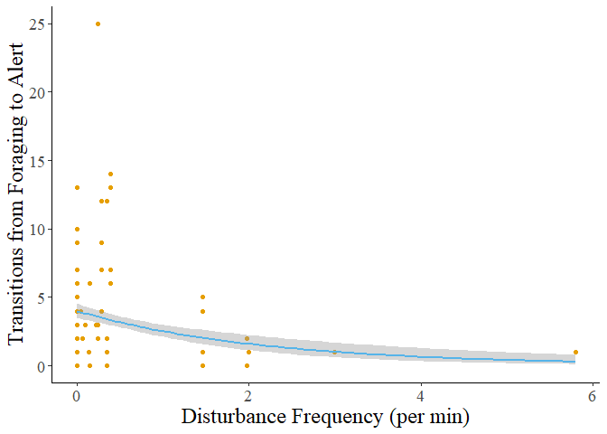

```r
PTWY.DOTPLOT.DISTURBANCE<- PTWY %>%
  ggplot(.
         , aes(x = DISTURBANCE_FREQUENCY
               , y = NB_HD.HU
               )
         ) +
  geom_point(colour = cbPalette[1]
             ) +
  geom_smooth(method = "glm"
              , method.args = list(family = poisson)
              , colour = cbPalette[2]
              ) +
  theme_classic() +
  xlab("Disturbance Frequency (per min)") +
  ylab("Transitions from Foraging to Alert")+
  theme(text = element_text(size = 18, family = "serif"))

PTWY.DOTPLOT.DISTURBANCE
```